# Data Exploration and Analysis: PUBPOL 599 Goverance Analytics

Melissa Greenaway

February 27, 2017

## Trim data set

Now, identify the variables we might be interested in, and create a new data frame with those variables:

```r
varsOfInterest=c("weight", "wave","dfs_adopt","urban_rural","employed","phone_own","phone_access","ppi_score","bank_own","age","ppi_cutoff","female","ed_level","literate","numerate","registered_MM","sim_ownoraccess","married","dfs_aware_gen","n_household","country")
crosswavesub=as.data.frame(dataStata)[varsOfInterest]
head(crosswavesub)
```

```
##   weight wave dfs_adopt urban_rural employed phone_own phone_access
## 1 0.5813    1         1           1        1         1          NaN
## 2 0.1709    1         0           2        0         1          NaN
## 3 0.5813    1         0           1        1         1          NaN
## 4 0.1290    1         0           2        1         1          NaN
## 5 0.5813    1         1           1        0         1          NaN
## 6 0.1290    1         0           2        1         1          NaN
##   ppi_score bank_own age ppi_cutoff female ed_level literate numerate
## 1        80        0  20          0      0        3        1        0
## 2        22        0  18          1      0        3        1        1
## 3        69        1  28          0      0        3        1        0
## 4        59        0  30          1      1        3        1        1
## 5        75        1  20          0      0        3        1        0
## 6        83        0  35          0      1        3        1        1
##   registered_MM sim_ownoraccess married dfs_aware_gen n_household country
## 1             1               1       0           NaN         NaN       3
## 2             0               1       0           NaN         NaN       3
## 3             0               1       1           NaN         NaN       3
## 4             0               1       0           NaN         NaN       3
## 5             1               1       0           NaN         NaN       3
## 6             0               1       1           NaN         NaN       3
```

## Save as R data file

Now we can save the file as an R-data structure, to speed up analysis.

```r
save(crosswavesub, file="crosswavesub.RData")
load("crosswavesub.RData")
head(crosswavesub)
```

```
##   weight wave dfs_adopt urban_rural employed phone_own phone_access
## 1 0.5813    1         1           1        1         1          NaN
## 2 0.1709    1         0           2        0         1          NaN
## 3 0.5813    1         0           1        1         1          NaN
## 4 0.1290    1         0           2        1         1          NaN
## 5 0.5813    1         1           1        0         1          NaN
## 6 0.1290    1         0           2        1         1          NaN
##   ppi_score bank_own age ppi_cutoff female ed_level literate numerate
## 1        80        0  20          0      0        3        1        0
## 2        22        0  18          1      0        3        1        1
## 3        69        1  28          0      0        3        1        0
## 4        59        0  30          1      1        3        1        1
## 5        75        1  20          0      0        3        1        0
## 6        83        0  35          0      1        3        1        1
##   registered_MM sim_ownoraccess married dfs_aware_gen n_household country
## 1             1               1       0           NaN         NaN       3
## 2             0               1       0           NaN         NaN       3
## 3             0               1       1           NaN         NaN       3
## 4             0               1       0           NaN         NaN       3
## 5             1               1       0           NaN         NaN       3
## 6             0               1       1           NaN         NaN       3
```

## Data Structure

In viewing the data’s structure, we see that each variable is “Atomic”, and contains STATA metadata.

```r
str(crosswavesub)
```

```
## 'data.frame':    228198 obs. of  21 variables:
##  $ weight         : atomic  0.581 0.171 0.581 0.129 0.581 ...
##   ..- attr(*, "label")= chr "survey weights"
##   ..- attr(*, "format.stata")= chr "%10.0g"
##  $ wave           : atomic  1 1 1 1 1 1 1 1 1 1 ...
##   ..- attr(*, "format.stata")= chr "%9.0g"
##  $ dfs_adopt      :Class 'labelled'  atomic [1:228198] 1 0 0 0 1 0 1 0 1 NaN ...
##   .. ..- attr(*, "label")= chr "person has ever used DFS for any financial activity (MM6A_1-5)"
##   .. ..- attr(*, "format.stata")= chr "%9.0g"
##   .. ..- attr(*, "labels")= Named num [1:2] 0 1
##   .. .. ..- attr(*, "names")= chr [1:2] "No" "Yes"
##  $ urban_rural    :Class 'labelled'  atomic [1:228198] 1 2 1 2 1 2 1 2 1 2 ...
##   .. ..- attr(*, "label")= chr "settlement size (AA7)"
##   .. ..- attr(*, "format.stata")= chr "%10.0g"
##   .. ..- attr(*, "labels")= Named num [1:2] 1 2
##   .. .. ..- attr(*, "names")= chr [1:2] "Urban" "Rural"
##  $ employed       :Class 'labelled'  atomic [1:228198] 1 0 1 1 0 1 1 1 1 1 ...
##   .. ..- attr(*, "label")= chr "Employed"
##   .. ..- attr(*, "format.stata")= chr "%10.0g"
##   .. ..- attr(*, "labels")= Named num [1:2] 0 1
##   .. .. ..- attr(*, "names")= chr [1:2] "No" "Yes"
##  $ phone_own      :Class 'labelled'  atomic [1:228198] 1 1 1 1 1 1 1 1 1 1 ...
##   .. ..- attr(*, "label")= chr "Person owns phone"
##   .. ..- attr(*, "format.stata")= chr "%10.0g"
##   .. ..- attr(*, "labels")= Named num [1:2] 0 1
##   .. .. ..- attr(*, "names")= chr [1:2] "No" "Yes"
##  $ phone_access   :Class 'labelled'  atomic [1:228198] NaN NaN NaN NaN NaN NaN NaN NaN NaN NaN ...
##   .. ..- attr(*, "label")= chr "person uses mobile phone belonging to someone else by borrowing or paying for it"
##   .. ..- attr(*, "format.stata")= chr "%10.0g"
##   .. ..- attr(*, "labels")= Named num [1:2] 0 1
##   .. .. ..- attr(*, "names")= chr [1:2] "No" "Yes"
##  $ ppi_score      : atomic  80 22 69 59 75 83 67 14 75 47 ...
##   ..- attr(*, "label")= chr "PPI_SCORE"
##   ..- attr(*, "format.stata")= chr "%10.0g"
##  $ bank_own       :Class 'labelled'  atomic [1:228198] 0 0 1 0 1 0 0 0 0 0 ...
##   .. ..- attr(*, "label")= chr "Person has bank account"
##   .. ..- attr(*, "format.stata")= chr "%10.0g"
##   .. ..- attr(*, "labels")= Named num [1:2] 0 1
##   .. .. ..- attr(*, "names")= chr [1:2] "No" "Yes"
##  $ age            : atomic  20 18 28 30 20 35 37 24 36 76 ...
```

[output cut: 33 more lines]

```
##   .. .. ..- attr(*, "names")= chr [1:2] "does not own or access a SIM" "owns or accesses a SIM"
##  $ married        :Class 'labelled'  atomic [1:228198] 0 0 1 0 0 1 0 1 0 1 ...
##   .. ..- attr(*, "label")= chr "Married: 0=not married 1=monog/poly married"
##   .. ..- attr(*, "format.stata")= chr "%9.0g"
##   .. ..- attr(*, "labels")= Named num [1:2] 0 1
##   .. .. ..- attr(*, "names")= chr [1:2] "No" "Yes"
##  $ dfs_aware_gen  : atomic  NaN NaN NaN NaN NaN NaN NaN NaN NaN NaN ...
##   ..- attr(*, "format.stata")= chr "%9.0g"
##  $ n_household    : atomic  NaN NaN NaN NaN NaN NaN NaN NaN NaN NaN ...
##   ..- attr(*, "label")= chr "number of members in household, incl. adults and children (DL26_1)"
##   ..- attr(*, "format.stata")= chr "%10.0g"
##  $ country        :Class 'labelled'  atomic [1:228198] 3 3 3 3 3 3 3 3 3 3 ...
##   .. ..- attr(*, "format.stata")= chr "%10.0g"
##   .. ..- attr(*, "labels")= Named num [1:8] 1 2 3 4 5 6 7 8
##   .. .. ..- attr(*, "names")= chr [1:8] "Kenya" "Nigeria" "Tanzania" "Uganda" ...
```

# Data Cleaning and Formatting

To begin cleaning, we’ll first change all NaNs to “NA”

```r
crosswavesub[crosswavesub=='NaN']=NA # this is an actual change to the data frame
```

Now we can format the variables:

```r
# Data Formatting package
library(sjmisc)
#country categories
labelvar=c(get_labels(crosswavesub$country)) # can save factor labels
labelvar
```

```
## [1] "Kenya"      "Nigeria"    "Tanzania"   "Uganda"     "Bangladesh"
## [6] "India"      "Indonesia"  "Pakistan"
```

```r
capture.output(to_factor(crosswavesub$country))
```

[output not shown]

[output cut: 2934 more lines]

```r
#fix country
crosswavesub$country=to_label(crosswavesub$country) # this is the command that works
```

```r
library(sjmisc)
levels(crosswavesub$country)
```

```
## [1] "Kenya"      "Nigeria"    "Tanzania"   "Uganda"     "Bangladesh"
## [6] "India"      "Indonesia"  "Pakistan"
```

```r
str(crosswavesub$country)
```

```
##  Factor w/ 8 levels "Kenya","Nigeria",..: 3 3 3 3 3 3 3 3 3 3 ...
```

```r
#urban rural - These are binary categories
crosswavesub$urban_rural=to_factor(crosswavesub$urban_rural)
#employed
crosswavesub$employed=to_factor(crosswavesub$employed)
#phone_own
crosswavesub$phone_own=to_factor(crosswavesub$phone_own)
#bank_own
crosswavesub$bank_own=to_factor(crosswavesub$bank_own)
#ppi_cutoff
crosswavesub$ppi_cutoff=to_factor(crosswavesub$ppi_cutoff)
#married
crosswavesub$married=to_label(crosswavesub$married)
#literate
crosswavesub$literate=to_factor(crosswavesub$literate)
#registered MM
crosswavesub$registered_MM=to_factor(crosswavesub$registered_MM)
#sim own or access
crosswavesub$sim_ownoraccess=to_factor(crosswavesub$sim_ownoraccess)
#numerate
crosswavesub$numerate=to_factor(crosswavesub$numerate)
#dfs adopt
crosswavesub$dfs_adopt=to_factor(crosswavesub$dfs_adopt) # this is the one
#wave
crosswavesub$wave=to_factor(crosswavesub$wave)
#age
is.numeric(crosswavesub$age) # making sure it's numeric
```

```
## [1] TRUE
```

```r
#n_household
is.numeric(crosswavesub$n_household) # same as above
```

```
## [1] TRUE
```

```r
# female
crosswavesub$female=to_factor(crosswavesub$female)
# Changing ed_level to factor, ordered
crosswavesub$ed_level=factor(crosswavesub$ed_level,ordered = T)
str(crosswavesub)
```

```
## 'data.frame':    228198 obs. of  21 variables:
##  $ weight         : atomic  0.581 0.171 0.581 0.129 0.581 ...
##   ..- attr(*, "label")= chr "survey weights"
##   ..- attr(*, "format.stata")= chr "%10.0g"
##  $ wave           : Factor w/ 3 levels "1","2","3": 1 1 1 1 1 1 1 1 1 1 ...
##  $ dfs_adopt      : Factor w/ 2 levels "0","1": 2 1 1 1 2 1 2 1 2 NA ...
##   ..- attr(*, "labels")= Named num  0 1
##   .. ..- attr(*, "names")= chr  "No" "Yes"
##   ..- attr(*, "label")= chr "person has ever used DFS for any financial activity (MM6A_1-5)"
##  $ urban_rural    : Factor w/ 2 levels "1","2": 1 2 1 2 1 2 1 2 1 2 ...
##   ..- attr(*, "labels")= Named num  1 2
##   .. ..- attr(*, "names")= chr  "Urban" "Rural"
##   ..- attr(*, "label")= chr "settlement size (AA7)"
##  $ employed       : Factor w/ 2 levels "0","1": 2 1 2 2 1 2 2 2 2 2 ...
##   ..- attr(*, "labels")= Named num  0 1
##   .. ..- attr(*, "names")= chr  "No" "Yes"
##   ..- attr(*, "label")= chr "Employed"
##  $ phone_own      : Factor w/ 2 levels "0","1": 2 2 2 2 2 2 2 2 2 2 ...
##   ..- attr(*, "labels")= Named num  0 1
##   .. ..- attr(*, "names")= chr  "No" "Yes"
##   ..- attr(*, "label")= chr "Person owns phone"
##  $ phone_access   :Class 'labelled'  atomic [1:228198] NA NA NA NA NA NA NA NA NA NA ...
##   .. ..- attr(*, "label")= chr "person uses mobile phone belonging to someone else by borrowing or paying for it"
##   .. ..- attr(*, "format.stata")= chr "%10.0g"
##   .. ..- attr(*, "labels")= Named num [1:2] 0 1
##   .. .. ..- attr(*, "names")= chr [1:2] "No" "Yes"
##  $ ppi_score      : atomic  80 22 69 59 75 83 67 14 75 47 ...
##   ..- attr(*, "label")= chr "PPI_SCORE"
##   ..- attr(*, "format.stata")= chr "%10.0g"
##  $ bank_own       : Factor w/ 2 levels "0","1": 1 1 2 1 2 1 1 1 1 1 ...
##   ..- attr(*, "labels")= Named num  0 1
##   .. ..- attr(*, "names")= chr  "No" "Yes"
##   ..- attr(*, "label")= chr "Person has bank account"
##  $ age            : atomic  20 18 28 30 20 35 37 24 36 76 ...
##   ..- attr(*, "label")= chr "Age"
##   ..- attr(*, "format.stata")= chr "%10.0g"
##  $ ppi_cutoff     : Factor w/ 2 levels "0","1": 1 2 1 2 1 1 1 2 1 2 ...
##   ..- attr(*, "labels")= Named num  0 1
##   .. ..- attr(*, "names")= chr  "Above poverty line" "Below poverty line"
##   ..- attr(*, "label")= chr "PPI: 0=income above $2.50/day 1=income below $2.50/day"
```

[output cut: 11 more lines]

```
##   .. ..- attr(*, "names")= chr  "No" "Yes"
##   ..- attr(*, "label")= chr "Numerate"
##  $ registered_MM  : Factor w/ 2 levels "0","1": 2 1 1 1 2 1 2 1 2 1 ...
##   ..- attr(*, "label")= chr "registered_MM"
##  $ sim_ownoraccess: Factor w/ 2 levels "0","1": 2 2 2 2 2 2 2 2 2 2 ...
##   ..- attr(*, "labels")= Named num  0 1
##   .. ..- attr(*, "names")= chr  "does not own or access a SIM" "owns or accesses a SIM"
##  $ married        : Factor w/ 2 levels "No","Yes": 1 1 2 1 1 2 1 2 1 2 ...
##   ..- attr(*, "label")= chr "Married: 0=not married 1=monog/poly married"
##  $ dfs_aware_gen  : atomic  NA NA NA NA NA NA NA NA NA NA ...
##   ..- attr(*, "format.stata")= chr "%9.0g"
##  $ n_household    : atomic  NA NA NA NA NA NA NA NA NA NA ...
##   ..- attr(*, "label")= chr "number of members in household, incl. adults and children (DL26_1)"
##   ..- attr(*, "format.stata")= chr "%10.0g"
##  $ country        : Factor w/ 8 levels "Kenya","Nigeria",..: 3 3 3 3 3 3 3 3 3 3 ...
```

```r
# changing
```

## Subset Data and Set Survey Weights

Create subset of data frames with each wave of data (for mapping of DFS adoption/use) and a subset with each country in wave 3. We also need to set survey weights for each subset of the data.

```r
library(survey)
#subset wave one data
wave1data=subset(crosswavesub,crosswavesub$wave=="1")
head(wave1data)
```

```
##   weight wave dfs_adopt urban_rural employed phone_own phone_access
## 1 0.5813    1         1           1        1         1           NA
## 2 0.1709    1         0           2        0         1           NA
## 3 0.5813    1         0           1        1         1           NA
## 4 0.1290    1         0           2        1         1           NA
## 5 0.5813    1         1           1        0         1           NA
## 6 0.1290    1         0           2        1         1           NA
##   ppi_score bank_own age ppi_cutoff female ed_level literate numerate
## 1        80        0  20          0      0        3        1        0
## 2        22        0  18          1      0        3        1        1
## 3        69        1  28          0      0        3        1        0
## 4        59        0  30          1      1        3        1        1
## 5        75        1  20          0      0        3        1        0
## 6        83        0  35          0      1        3        1        1
##   registered_MM sim_ownoraccess married dfs_aware_gen n_household  country
## 1             1               1      No            NA          NA Tanzania
## 2             0               1      No            NA          NA Tanzania
## 3             0               1     Yes            NA          NA Tanzania
## 4             0               1      No            NA          NA Tanzania
## 5             1               1      No            NA          NA Tanzania
## 6             0               1     Yes            NA          NA Tanzania
```

```r
w1weight= svydesign(id=~1, weights=wave1data$weight,data=wave1data)

#subset wave two data
wave2data=subset(crosswavesub,crosswavesub$wave=="2")
head(wave2data)
```

```
##        weight wave dfs_adopt urban_rural employed phone_own phone_access
## 2998 1.425542    2         1           1        0         1           NA
## 2999 1.360723    2         1           1        0         1           NA
## 3000 1.360723    2         1           1        0         0            1
## 3001 1.360723    2         1           1        0         0            1
## 3002 1.360723    2         1           1        0         1           NA
## 3003 1.323590    2         0           1        0         0            0
##      ppi_score bank_own age ppi_cutoff female ed_level literate numerate
## 2998        57        0  15          1      0        3        1        1
## 2999        60        0  15          1      1        2        1        1
## 3000        55        0  15          1      1        2        1        1
## 3001        51        0  15          1      1        2        1        1
## 3002        47        0  15          1      1        3        1        1
## 3003        21        0  15          1      0        3        1        1
##      registered_MM sim_ownoraccess married dfs_aware_gen n_household
## 2998             1               1      No             1           8
## 2999             1               1      No             1           5
## 3000             0               1      No             1           9
## 3001             0               1      No             1           7
## 3002             1               1      No             1           7
## 3003             0               0      No             1           6
##       country
## 2998 Tanzania
## 2999 Tanzania
## 3000 Tanzania
## 3001 Tanzania
## 3002 Tanzania
## 3003 Tanzania
```

```r
w2weight= svydesign(id=~1, weights=wave2data$weight,data=wave2data)

#subset wave three data
wave3data<-subset(crosswavesub,crosswavesub$wave=="3")
head(wave3data)
```

```
##       weight wave dfs_adopt urban_rural employed phone_own phone_access
## 5998 1.36069    3         1           1        1         1           NA
## 5999 1.36069    3         1           1        1         1           NA
## 6000 1.36069    3         1           1        0         1           NA
## 6001 1.36069    3         0           1        0         1           NA
## 6002 1.36069    3         1           1        1         1           NA
## 6003 1.36069    3         1           1        1         1           NA
##      ppi_score bank_own age ppi_cutoff female ed_level literate numerate
## 5998        60        0  34          1      0        2        1        1
## 5999        65        0  31          1      1        2        1        1
## 6000        53        0  NA          1      1        3        1        1
## 6001        72        0  25          0      1        3        1        1
## 6002        65        0  39          1      1        2        1        1
## 6003        76        1  58          0      0        3        1        1
##      registered_MM sim_ownoraccess married dfs_aware_gen n_household
## 5998          <NA>               1      No             1           1
## 5999          <NA>               1      No             1           6
## 6000          <NA>               1      No             1           5
## 6001          <NA>               1      No             1           1
## 6002          <NA>               1     Yes             1           6
## 6003          <NA>               1     Yes             1           6
##       country
## 5998 Tanzania
## 5999 Tanzania
## 6000 Tanzania
## 6001 Tanzania
## 6002 Tanzania
## 6003 Tanzania
```

```r
w3weight= svydesign(id=~1, weights=wave3data$weight,data=wave3data)

#subset wave three data by country, for easier analysis
kenya3data<-subset(wave3data,wave3data$country=="Kenya")
k3weight= svydesign(id=~1, weights=kenya3data$weight,data=kenya3data)

nig3data<-subset(wave3data,wave3data$country=="Nigeria")
n3weight= svydesign(id=~1, weights=nig3data$weight,data=nig3data)

ind3data<-subset(wave3data,wave3data$country=="India")
ind3weight= svydesign(id=~1, weights=ind3data$weight,data=ind3data)

indo3data<-subset(wave3data,wave3data$country=="Indonesia")
indo3weight= svydesign(id=~1, weights=indo3data$weight,data=indo3data)

tan3data<-subset(wave3data,wave3data$country=="Tanzania")
t3weight= svydesign(id=~1, weights=tan3data$weight,data=tan3data)

u3data<-subset(wave3data,wave3data$country=="Uganda")
u3weight= svydesign(id=~1, weights=u3data$weight,data=u3data)

b3data<-subset(wave3data,wave3data$country=="Bangladesh")
b3weight= svydesign(id=~1, weights=b3data$weight,data=b3data)

p3data<-subset(wave3data,wave3data$country=="Pakistan")
p3weight= svydesign(id=~1, weights=p3data$weight,data=p3data)
```

## Data Exploration

With the subsets of data, we can generate weighted proportions of our variables for each country in wave 3:

```r
#WAVE 3
prop_ed3=svyby(~ed_level, ~country, w3weight, svymean, na.rm = TRUE)
prop_emp3=svyby(~employed, ~country, w3weight, svymean, na.rm = TRUE)
prop_bank3=svyby(~bank_own, ~country, w3weight, svymean, na.rm = TRUE)
prop_marr3=svyby(~married, ~country, w3weight, svymean, na.rm = TRUE)
prop_lit3=svyby(~literate, ~country, w3weight, svymean, na.rm = TRUE)
prop_num3=svyby(~numerate, ~country, w3weight, svymean, na.rm = TRUE)
prop_sim3=svyby(~sim_ownoraccess, ~country, w3weight, svymean, na.rm = TRUE)
prop_marr3=svyby(~married, ~country, w3weight, svymean, na.rm = TRUE)
prop_fem3=svyby(~female, ~country, w3weight, svymean, na.rm = TRUE)

prop_ed3 # example
```

```
##               country  ed_level1 ed_level2 ed_level3 se.ed_level1
## Kenya           Kenya 0.08572821 0.4346036 0.4796682  0.005048384
## Nigeria       Nigeria 0.09681559 0.1422768 0.7609076  0.005080836
## Tanzania     Tanzania 0.09529870 0.6608543 0.2438470  0.005951385
## Uganda         Uganda 0.13631103 0.4783142 0.3853748  0.007305217
## Bangladesh Bangladesh 0.25976202 0.2556969 0.4845411  0.005714844
## India           India 0.29088220 0.3022757 0.4068421  0.002207120
## Indonesia   Indonesia 0.03496921 0.5849221 0.3801087  0.002263869
## Pakistan     Pakistan 0.31548616 0.2181586 0.4663552  0.006213959
##            se.ed_level2 se.ed_level3
## Kenya       0.009792877  0.009949428
## Nigeria     0.005690737  0.006978561
## Tanzania    0.009897236  0.009132521
## Uganda      0.011243454  0.011237634
## Bangladesh  0.006031109  0.006904727
## India       0.002321316  0.002542468
## Indonesia   0.006854916  0.006816000
## Pakistan    0.005537118  0.006790489
```

Let’s test for differences by education level:

```r
# education differences, adoption
tablee <- svytable(~ed_level+country, w3weight)
tablee
```

```
##         country
## ed_level      Kenya    Nigeria   Tanzania     Uganda Bangladesh      India
##        1   254.1844   553.9650   285.0224   407.6899  1557.8310 13079.7896
##        2  1288.6006   814.0873  1976.5039  1430.5802  1533.4518 13592.1087
##        3  1422.2175  4353.8051   729.3054  1152.6096  2905.8640 18294.0355
##         country
## ed_level  Indonesia   Pakistan
##        1   211.7116  1889.6376
##        2  3541.2518  1306.6840
##        3  2301.2651  2793.2838
```

```r
svychisq(~ed_level+country, w3weight)
```

```
##
##  Pearson's X^2: Rao & Scott adjustment
##
## data:  svychisq(~ed_level + country, w3weight)
## F = 481.02, ndf = 1.3575e+01, ddf = 1.0601e+06, p-value < 2.2e-16
```

Now testing for differences in DFS adoption rates by country:

```r
# test for differences
table <- svytable(~dfs_adopt+country, w3weight) # cross tab
summary(table, statistic="Chisq") # differences present by country
```

```
##          country
## dfs_adopt Kenya Nigeria Tanzania Uganda Bangladesh India Indonesia
##         0   572     633      907   1294       3537  4362       463
##         1  2332      50     1850   1420       1988   237        27
##          country
## dfs_adopt Pakistan
##         0     3775
##         1      556
##
##  Pearson's X^2: Rao & Scott adjustment
##
## data:  svychisq(~dfs_adopt + country, design = w3weight, statistic = "Chisq")
## X-squared = 23939, df = 7, p-value < 2.2e-16
```

Differences for gender?

```r
# gender differences, adoption
tablef <- svytable(~dfs_adopt+female+country, w3weight)
tablef
```

```
## , , country = Kenya
##
##          female
## dfs_adopt          0          1
##         0  250.21595  322.13376
##         1 1178.20564 1154.09407
##
## , , country = Nigeria
##
##          female
## dfs_adopt          0          1
##         0  377.10749  255.43550
##         1   33.46740   16.39409
##
## , , country = Tanzania
##
##          female
## dfs_adopt          0          1
##         0  422.20405  484.83194
##         1  964.32489  885.84427
##
## , , country = Uganda
##
##          female
## dfs_adopt          0          1
##         0  549.31560  744.38846
##         1  736.74401  682.83947
##
## , , country = Bangladesh
##
##          female
## dfs_adopt          0          1
##         0 1544.98071 1991.95822
##         1 1385.26934  603.01447
##
## , , country = India
##
##          female
## dfs_adopt          0          1
##         0 3090.81838 1270.94486
##         1  210.23490   26.71170
##
## , , country = Indonesia
##
##          female
## dfs_adopt          0          1
##         0  244.02576  219.06708
##         1   11.99176   14.97691
##
## , , country = Pakistan
##
##          female
## dfs_adopt          0          1
##         0 2080.42353 1694.50085
##         1  433.30940  122.51997
```

```r
svychisq(~dfs_adopt+female, w3weight) # over all countries, differences
```

```
##
##  Pearson's X^2: Rao & Scott adjustment
##
## data:  svychisq(~dfs_adopt + female, w3weight)
## F = 22.193, ndf = 1, ddf = 78091, p-value = 2.47e-06
```

## Plot education levels by country

Plotting education levels by country:

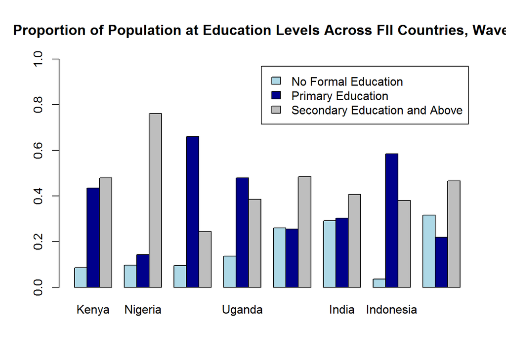

```r
table_ed=svytable(~ed_level+country, w3weight)
legendplot_ed=levels(as.factor(unique(wave3data$ed_level)))
bartable=table_ed
barplot(prop_ed3, beside=TRUE, legend=c("No Formal Education", "Primary Education", "Secondary Education and Above"), ylim=c(0,1), col=c("lightblue","darkblue","gray"), main="Proportion of Population at Education Levels Across FII Countries, Wave 3") # plotting proportions
```

## Plot histogram distributions for age

Plotting age distributions by country

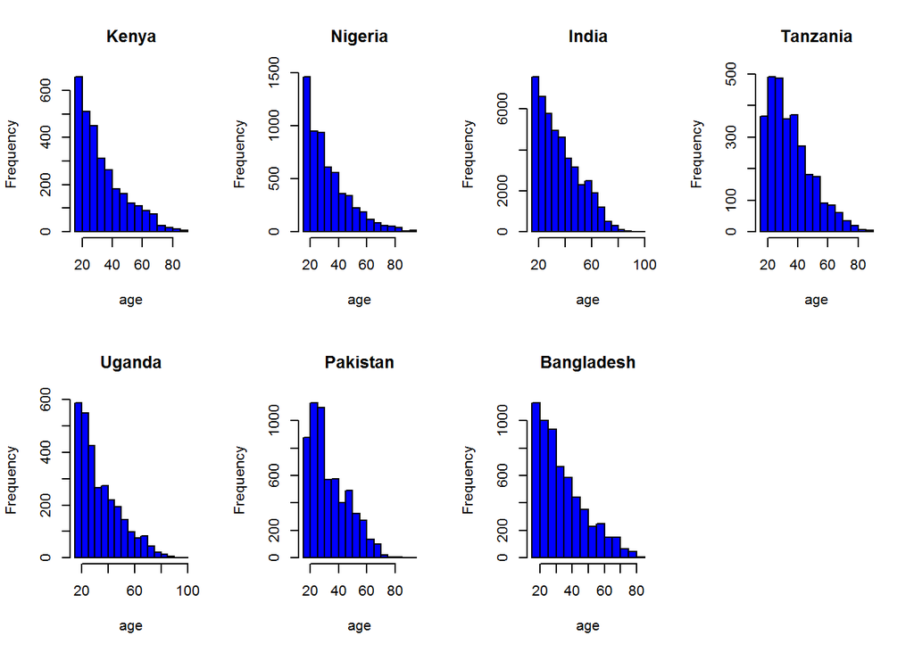

```r
# all together now
par(mfrow=c(2,4))
svyhist(~age, k3weight, main = "Kenya", col="blue", prob=FALSE)
svyhist(~age, n3weight, main = "Nigeria", col="blue", prob=FALSE)
svyhist(~age, ind3weight, main = "India", col="blue", prob=FALSE)
svyhist(~age, t3weight, main = "Tanzania", col="blue", prob=FALSE)
svyhist(~age, u3weight, main = "Uganda", col="blue", prob=FALSE)
svyhist(~age, p3weight, main = "Pakistan", col="blue", prob=FALSE)
svyhist(~age, b3weight, main = "Bangladesh", col="blue", prob=FALSE)
```

## Calculating average DFS adoption rates

```r
# putting means for DFS adoption into separate frame
#means, wave 1
means1 <- svyby(~dfs_adopt,~country,design=w1weight,svymean,na.rm=TRUE)
means1
```

```
##               country dfs_adopt0 dfs_adopt1 se.dfs_adopt0 se.dfs_adopt1
## Kenya           Kenya  0.2219138 0.77808617   0.013637544   0.013637544
## Nigeria       Nigeria  0.9742324 0.02576765   0.006644355   0.006644355
## Tanzania     Tanzania  0.4913445 0.50865547   0.012275892   0.012275892
## Uganda         Uganda  0.5199174 0.48008257   0.009819576   0.009819576
## Bangladesh Bangladesh  0.7492350 0.25076502   0.006451274   0.006451274
## India           India  0.9533595 0.04664055   0.005058072   0.005058072
## Pakistan     Pakistan  0.8907561 0.10924388   0.005240527   0.005240527
```

```r
#means, wave 2
means2 <- svyby(~dfs_adopt,~country,design=w2weight,svymean,na.rm=TRUE)
means2
```

```
##               country dfs_adopt0 dfs_adopt1 se.dfs_adopt0 se.dfs_adopt1
## Kenya           Kenya  0.2365196 0.76348043   0.012195905   0.012195905
## Nigeria       Nigeria  0.9417698 0.05823021   0.009525863   0.009525863
## Tanzania     Tanzania  0.4941950 0.50580499   0.010062980   0.010062980
## Uganda         Uganda  0.5316786 0.46832141   0.011717636   0.011717636
## Bangladesh Bangladesh  0.7518368 0.24816318   0.006389173   0.006389173
## India           India  0.9793671 0.02063293   0.002343616   0.002343616
## Indonesia   Indonesia  0.9861327 0.01386733   0.007071719   0.007071719
## Pakistan     Pakistan  0.8902202 0.10977984   0.004840304   0.004840304
```

```r
#means, wave 3
means3 <- svyby(~dfs_adopt, ~country, design = w3weight, svymean, na.rm=TRUE)
means3
```

```
##               country dfs_adopt0 dfs_adopt1 se.dfs_adopt0 se.dfs_adopt1
## Kenya           Kenya  0.1970461 0.80295394   0.008599796   0.008599796
## Nigeria       Nigeria  0.9269326 0.07306736   0.009155548   0.009155548
## Tanzania     Tanzania  0.3289694 0.67103065   0.009870803   0.009870803
## Uganda         Uganda  0.4768032 0.52319684   0.011922626   0.011922626
## Bangladesh Bangladesh  0.6401441 0.35985587   0.007046753   0.007046753
## India           India  0.9484754 0.05152458   0.004076814   0.004076814
## Indonesia   Indonesia  0.9449688 0.05503118   0.011392804   0.011392804
## Pakistan     Pakistan  0.8716553 0.12834472   0.005258273   0.005258273
```

## Aggregating Means together

Preparing average DFS adoption rates data for mapping:

```r
## aggregate means data into data frame ##
names(means2)[names(means2)=="dfs_adopt1"]="dfs_adopt2"
means2=means2[,c("country","dfs_adopt2")]
names(means3)[names(means3)=="dfs_adopt1"]="dfs_adopt3"
means3=means3[,c("country","dfs_adopt3")]

dfs_adopt_means=means1[,c("country","dfs_adopt1")]
dfs_adopt_means=merge(dfs_adopt_means,means2, by.x="country",by.y="country")
dfs_adopt_means=merge(dfs_adopt_means,means3, by.x="country", by.y = "country")

#change numbers to percentages
dfs_adopt_means$dfs_adopt1=dfs_adopt_means$dfs_adopt1*100
dfs_adopt_means$dfs_adopt2=dfs_adopt_means$dfs_adopt2*100
dfs_adopt_means$dfs_adopt3=dfs_adopt_means$dfs_adopt3*100

head(dfs_adopt_means)
```

```
##      country dfs_adopt1 dfs_adopt2 dfs_adopt3
## 1 Bangladesh  25.076502  24.816318  35.985587
## 2      India   4.664055   2.063293   5.152458
## 3      Kenya  77.808617  76.348043  80.295394
## 4    Nigeria   2.576765   5.823021   7.306736
## 5   Pakistan  10.924388  10.977984  12.834472
## 6   Tanzania  50.865547  50.580499  67.103065
```

## Mapping

Import map and prepare to plot data:

```r
# Get Map
library(maptools)
folder="Data/TM_WORLD_BORDERS-0.3/"
fileName="TM_WORLD_BORDERS-0.3.shp"
fileSHP=file.path(folder,fileName)
globalmap =readShapeSpatial(fileSHP)
head(globalmap@data)
```

```
##   FIPS ISO2 ISO3 UN                NAME   AREA  POP2005 REGION SUBREGION
## 0   AC   AG  ATG 28 Antigua and Barbuda     44    83039     19        29
## 1   AG   DZ  DZA 12             Algeria 238174 32854159      2        15
## 2   AJ   AZ  AZE 31          Azerbaijan   8260  8352021    142       145
## 3   AL   AL  ALB  8             Albania   2740  3153731    150        39
## 4   AM   AM  ARM 51             Armenia   2820  3017661    142       145
## 5   AO   AO  AGO 24              Angola 124670 16095214      2        17
##       LON     LAT
## 0 -61.783  17.078
## 1   2.632  28.163
## 2  47.395  40.430
## 3  20.068  41.143
## 4  44.563  40.534
## 5  17.544 -12.296
```

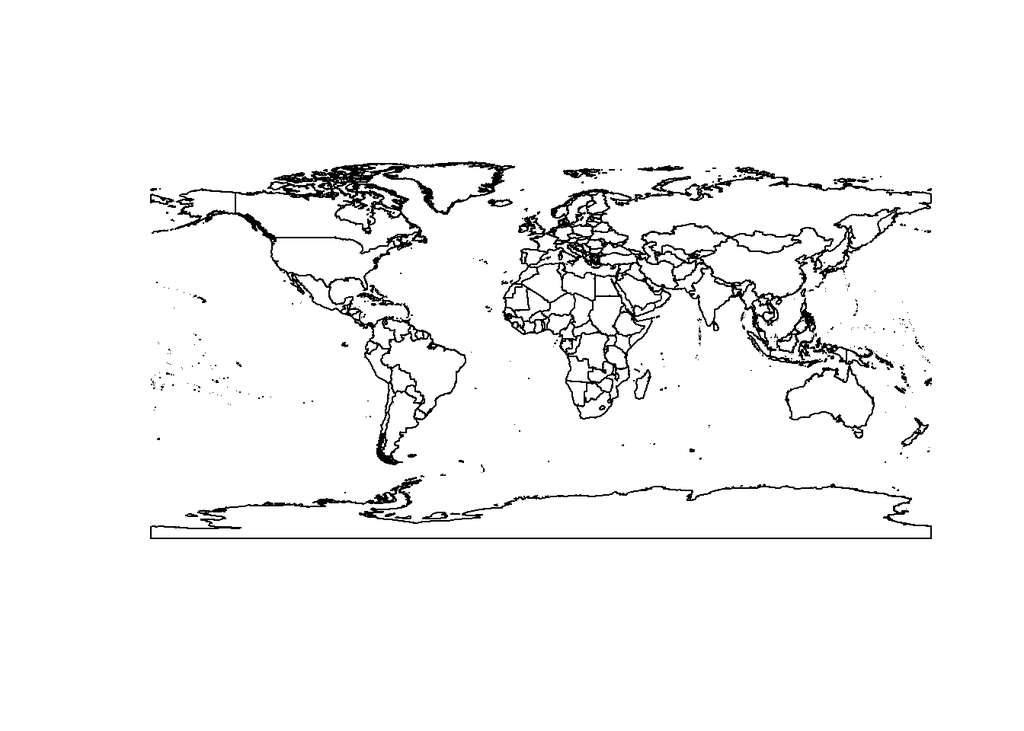

```r
plot(globalmap)
```

Merge map data and DFS adoption rates:

```r
str(globalmap$NAME)
```

```
##  Factor w/ 246 levels "Afghanistan",..: 10 4 16 3 12 7 5 11 14 18 ...
```

```r
str(dfs_adopt_means)
```

```
## 'data.frame':    7 obs. of  4 variables:
##  $ country   : Factor w/ 8 levels "Kenya","Nigeria",..: 5 6 1 2 8 3 4
##  $ dfs_adopt1: num  25.08 4.66 77.81 2.58 10.92 ...
##  $ dfs_adopt2: num  24.82 2.06 76.35 5.82 10.98 ...
##  $ dfs_adopt3: num  35.99 5.15 80.3 7.31 12.83 ...
```

```r
globalmap =merge(globalmap,dfs_adopt_means,by.x='NAME',by.y='country',all.x=T)
```

Subset map for the regions with FII countries:

```r
table(globalmap@data$REGION)
```

```
##
##   0   2   9  19 142 150
##  10  57  25  53  50  51
```

```r
globalmap@data[,c('NAME','REGION')]
```

```
##                                          NAME REGION
## 10                        Antigua and Barbuda     19
## 4                                     Algeria      2
## 16                                 Azerbaijan    142
## 3                                     Albania    150
## 12                                    Armenia    142
## 7                                      Angola      2
## 5                              American Samoa      9
## 11                                  Argentina     19
## 14                                  Australia      9
## 18                                    Bahrain    142
## 20                                   Barbados     19
## 25                                    Bermuda     19
## 17                                    Bahamas     19
## 19                                 Bangladesh    142
```

[output cut: 232 more lines]

```r
subMap=globalmap[globalmap@data$REGION%in%c('2','142'),]
```

Map DFS adoption rates by country, Wave 1:

[figure not shown]

```r
# make sure packages are installed
library(RColorBrewer)
library(classInt)

# wave 1
varToPLot=subMap@data$dfs_adopt1
numberOfClasses = 3
colorForScale='Greens'
title='DFS Adoption Rates by Country, Wave 1'

#plotting, wave 1
colors <- brewer.pal(numberOfClasses, colorForScale)
intervals <- classIntervals(varToPLot, numberOfClasses, style = "equal",dataPrecision=2)
colorPallette <- findColours(intervals, colors)
plot(subMap, col = colorPallette,main=title)
legend(-65,10, legend = names(attr(colorPallette, "table")), y.intersp=0.5, x.intersp=0.5, fill = attr(colorPallette, "palette"), cex = 0.75, bty = "n")
```

Wave 2:

[figure not shown]

```r
# wave 2
varToPLot=subMap@data$dfs_adopt2
numberOfClasses = 3
colorForScale='Greens'
title='DFS Adoption Rates by Country, Wave 2'

#plotting, wave 2
colors <- brewer.pal(numberOfClasses, colorForScale)
intervals <- classIntervals(varToPLot, numberOfClasses, style = "equal",dataPrecision=2)
colorPallette <- findColours(intervals, colors)
plot(subMap, col = colorPallette,main=title)
legend(-65,10, legend = names(attr(colorPallette, "table")), y.intersp=0.5, x.intersp=0.5, fill = attr(colorPallette, "palette"), cex = 0.75, bty = "n")
```

Wave 3:

[figure not shown]

```r
# wave 3
varToPLot=subMap@data$dfs_adopt3
numberOfClasses = 3
colorForScale='Greens'
title='DFS Adoption Rates by Country, Wave 3'

#plotting, wave 3
colors <- brewer.pal(numberOfClasses, colorForScale)
intervals <- classIntervals(varToPLot, numberOfClasses, style = "equal",dataPrecision=2)
colorPallette <- findColours(intervals, colors)
plot(subMap, col = colorPallette,main=title)
legend(-65,10, legend = names(attr(colorPallette, "table")), y.intersp=0.5, x.intersp=0.5, fill = attr(colorPallette, "palette"), cex = 0.75, bty = "n")
```